# For S4

**Codebook:**

`CID` unique identifier for each connection

`MenteeID` unique identifier of the trainee.

`MentorID` unique identifier of the mentor.

`MentorshipType` integer coding the type of relationship: (What does “4” mean?)

- 0=undergrad research assistant,
- 1=graduate student,
- 2=postdoctoral fellow,
- 3=research scientist.

`Institution` string name of institution where training took place (it’s raw, is there a solution on zenodo.org?)

`StopYear` year of graduation/training completed (what is -1?)

`gender_t`, `gender_m` gender by first name (using the dataset available at zenodo.org)

`ResearchArea_t`, `ResearchArea_m`- first research area (from the full list of each person’s areas, only the first is taken)

```
## Rows: 742,766
## Columns: 10
## $ CID            <dbl> 2, 3, 5, 17, 18, 19, 25, 36, 44, 58, 106, 105, 111, 1, …
## $ MenteeID       <dbl> 2, 4, 6, 27, 28, 8, 5, 17, 7, 60, 33, 105, 108, 1, 521,…
## $ MentorID       <dbl> 3, 3, 3, 3, 3, 3, 3, 3, 3, 3, 3, 3, 3, 3, 3, 3, 3, 3, 3…
## $ MentorshipType <dbl> 1, 2, 1, 1, 2, 1, 1, 1, 2, 1, 4, 1, 2, 1, 2, 2, 1, 1, 1…
## $ Institution    <chr> "University of California, Berkeley", "University of Ca…
## $ StopYear       <dbl> 2005, 2006, 2008, -1, -1, 2006, 2009, 2002, 2004, 2007,…
## $ ResearchArea_t <chr> "neuro", "neuro", "neuro", "neuro", "neuro", "neuro", "…
## $ ResearchArea_m <chr> "neuro", "neuro", "neuro", "neuro", "neuro", "neuro", "…
## $ gender_t       <chr> "man", "man", "man", "man", "woman", "woman", "unknown"…
## $ gender_m       <chr> "man", "man", "man", "man", "man", "man", "man", "man",…
```

## Areas

#### Figure 1: Gender structure by main areas

##### Mentors

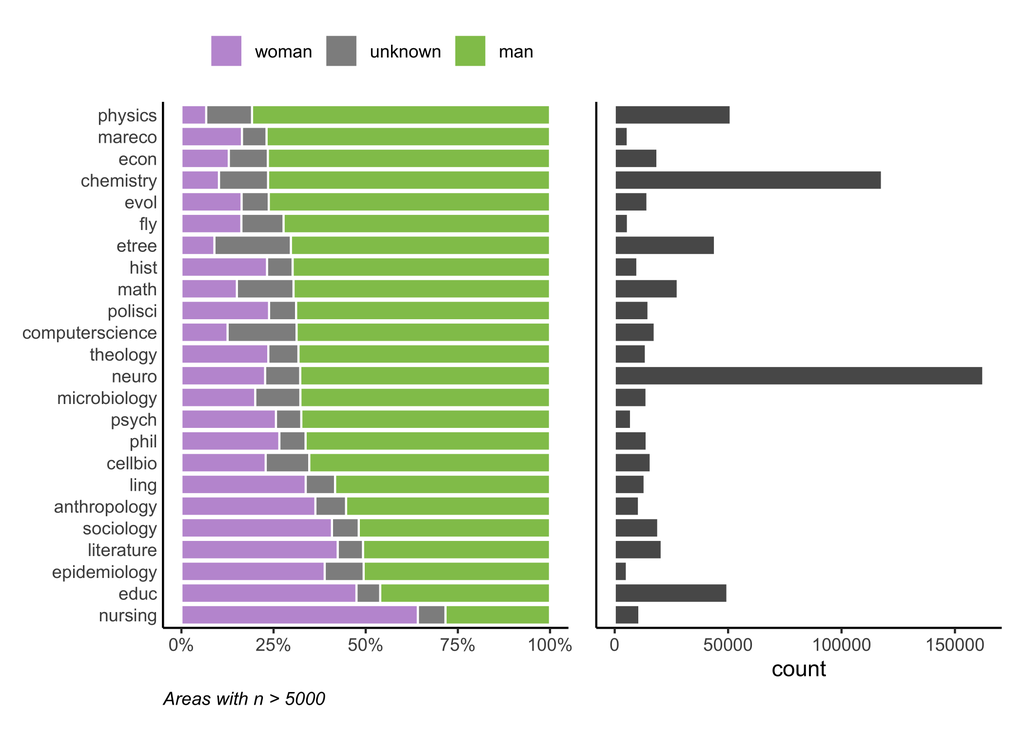

##### Trainees

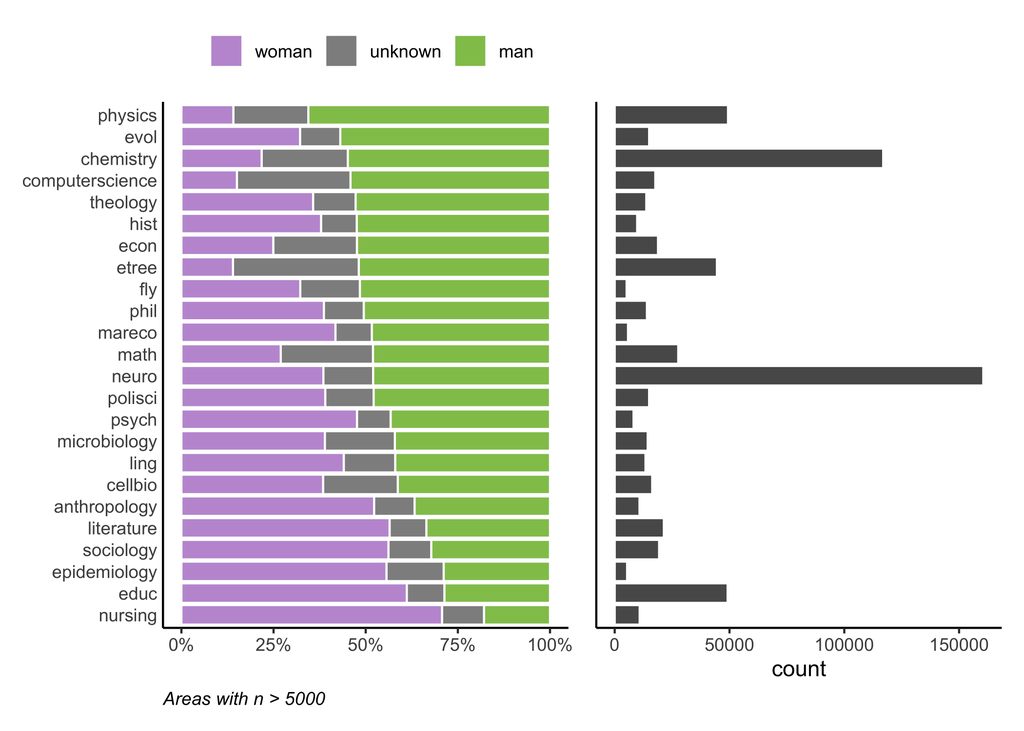

## Years

#### Figure 2: Count mentors by years

##### Total

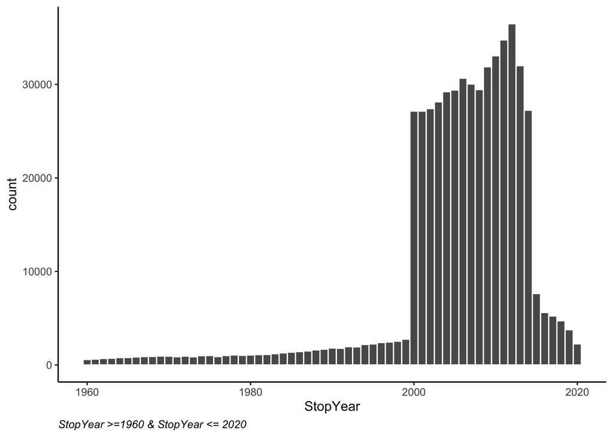

##### By main areas

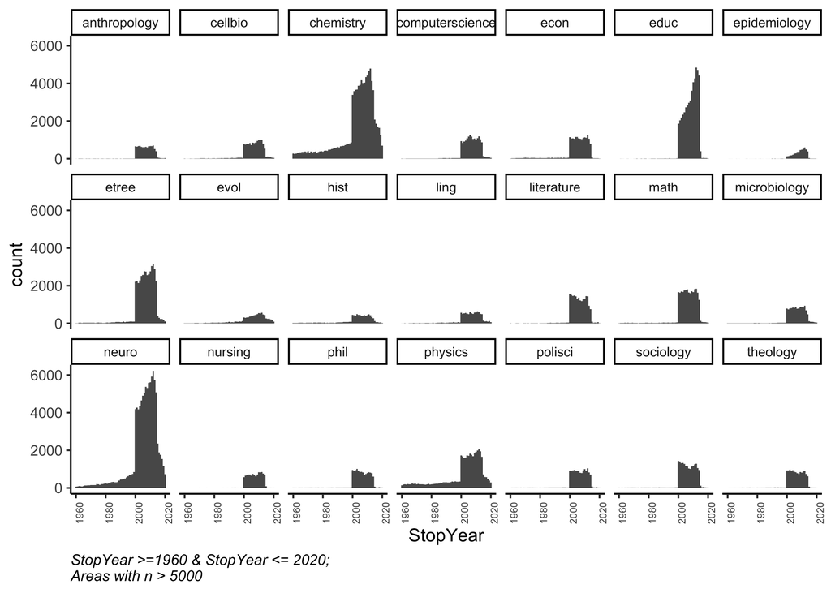

## MentorshipType

|  | Overall (N=742766) |
| --- | --- |
| as.character(MentorshipType) |  |
| 0 | 18838 (2.5%) |
| 1 | 630099 (84.8%) |
| 2 | 68618 (9.2%) |
| 3 | 7402 (1.0%) |
| 4 | 17809 (2.4%) |

## Reflection: what is “family”?

[figure not shown]

Family 1. Single parent with child

Family 2. Single parent: large family with twins

Family 3. Two parents with a child

Family 4. Mixed, with stepparents/stepbrothers/stepsisters

Family 5. …

Conditions trainee entering the “Family”:

- through the “parent”(mentor) - necessary condition
- through the overlapping study period with other trainees, OR/AND trainees should have the same area (?) OR/AND trainees’ co-publications during the study with one mentor and n years after StopYear (?)

Conditions then mentor entering the “Family”(?) - need to look at reverse logic?